# Did fertiliser price changes go with later wheat price changes?

World Bank monthly commodity prices, from 2015 to the latest month available

Shruti Singla

11 November 2026

# 1. Question

Fertiliser is a major cost of growing wheat. **Did monthly changes in fertiliser prices (DAP and urea) go together with later monthly changes in wheat prices, and over what delay?** I use the 2021 to 2022 fertiliser price spike as a natural episode to look at, but the models use the whole sample.

This is a descriptive time-series study. It measures **association and predictive order**, not proven cause and effect.

# 2. Data

- **Source:** World Bank, Commodity Markets (“Pink Sheet”), monthly prices in **nominal US dollars**. File status: *Updated on November 03, 2026*.
- **Sample:** January 2015 to October 2026 (142 months). Thirteen earlier months are used only to build lagged values.
- **Series used:**

| Series | Column in World Bank file | Unit |
| --- | --- | --- |
| Wheat (US HRW) | Wheat, US HRW | ($/mt) |
| DAP | DAP | ($/mt) |
| Urea | Urea | ($/mt) |
| Crude oil (average) | Crude oil, average | ($/bbl) |
| Natural gas (Europe) | Natural gas, Europe | ($/mmbtu) |

**Cleaning and checks** (full list in `output/tables/data_validation.csv`): the date column was parsed from the World Bank format (for example `2021M06`); the placeholder for missing values was converted to missing; the monthly sequence was checked for gaps and duplicates; prices were checked to be positive; one-month moves larger than 25% were flagged for inspection (`output/tables/outlier_flags.csv`) but not removed, because they correspond to genuine market swings rather than errors.

| Check | Result |
| --- | --- |
| duplicate months | 0 |
| missing months in sequence | 0 |
| trailing months dropped (required series missing) | 0 |
| non-positive price values | 0 |
| one-month moves larger than 25% (log change), flagged not removed | 28 |
| first month retained (burn-in for lags) | 2013-12-01 |
| first month of analysis sample | 2015-01-01 |
| last month | 2026-10-01 |
| months in analysis sample | 142 |
| synthetic test file | FALSE |

# 3. Method

1. **Monthly log changes.** Price levels trend and wander, so regressing one level on another can look significant by accident. I work with monthly log changes (roughly monthly percentage changes). Augmented Dickey-Fuller (ADF) tests below: a small p-value supports stationarity (the p-values from this test are bounded between 0.01 and 0.99).

| Series | Transformation | n | ADF statistic | p-value |
| --- | --- | --- | --- | --- |
| Wheat (US HRW) | log price (level) | 142 | -1.854 | 0.637 |
| DAP | log price (level) | 142 | -2.737 | 0.269 |
| Urea | log price (level) | 142 | -2.641 | 0.310 |
| Wheat (US HRW) | monthly log change | 142 | -3.904 | 0.016 |
| DAP | monthly log change | 142 | -3.429 | 0.053 |
| Urea | monthly log change | 142 | -5.021 | 0.010 |

*Note: for DAP the test does not reject a unit root at the 5% level (p = 0.053), so stationarity of its monthly changes is borderline.*

2. **Lead-lag correlations** between wheat now and fertiliser *k* months earlier.
3. **Distributed-lag regression (main model, window fixed in advance: months 0 to 6).** Wheat change on fertiliser change today and in the previous 6 months, plus lagged changes in crude oil and European natural gas as controls. Standard errors are **Newey-West (HAC)** because monthly price changes are usually autocorrelated. The **cumulative association** is the sum of the lag coefficients.
4. **Granger-type tests in both directions**, because high wheat prices could also pull fertiliser prices up.
5. **Robustness and sensitivity:** other lag lengths, with and without energy controls, two targeted sensitivity checks, and three sub-periods. A 12-month window is shown separately as **exploratory**, because it was added after the main results were seen.

# 4. Findings

## 4.1 Prices over time

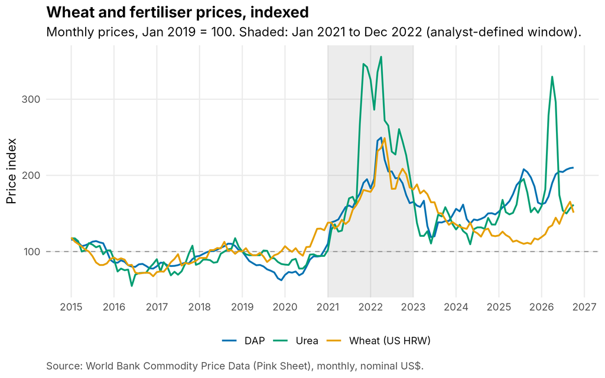

## 4.2 Main estimates

Both variables are in logs, so a coefficient reads as a percentage response. The **cumulative association** is the total across the window: it says by how many percent wheat prices are higher (or lower) by the end of the window, in association with a one-off 1% rise in the fertiliser price.

- **DAP:** cumulative association over months 0-6 = **0.40** (95% CI 0.02 to 0.78; n = 142). In words: a one-off 1% rise in the price goes with wheat prices about 0.4% higher by the end of the window. The interval excludes zero, so the estimate is distinguishable from zero at the 5% level. Adjusted R-squared of the model: 0.04.
- **Urea:** cumulative association over months 0-6 = **0.41** (95% CI 0.17 to 0.65; n = 142). In words: a one-off 1% rise in the price goes with wheat prices about 0.4% higher by the end of the window. The interval excludes zero, so the estimate is distinguishable from zero at the 5% level. Adjusted R-squared of the model: 0.10.

Low R-squared values mean that most month-to-month movement in wheat prices is **not** explained by fertiliser and energy price changes.

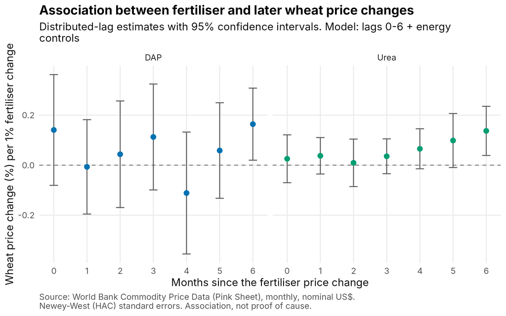

## 4.3 Timing: which delays matter?

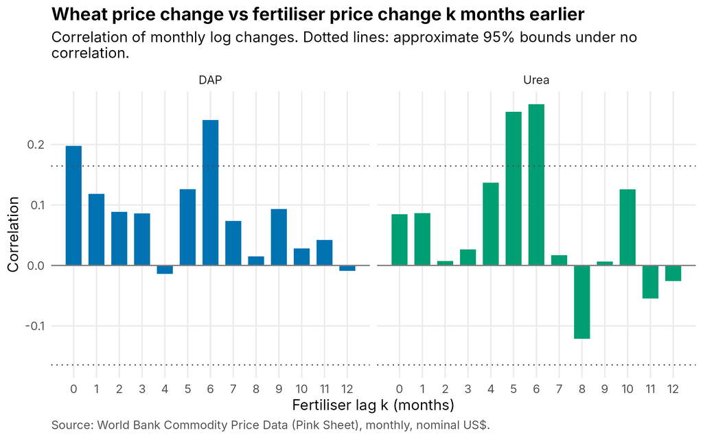

**Exploratory, added after seeing the main results:** the same model with a 12-month window, to check what happens beyond month 6.

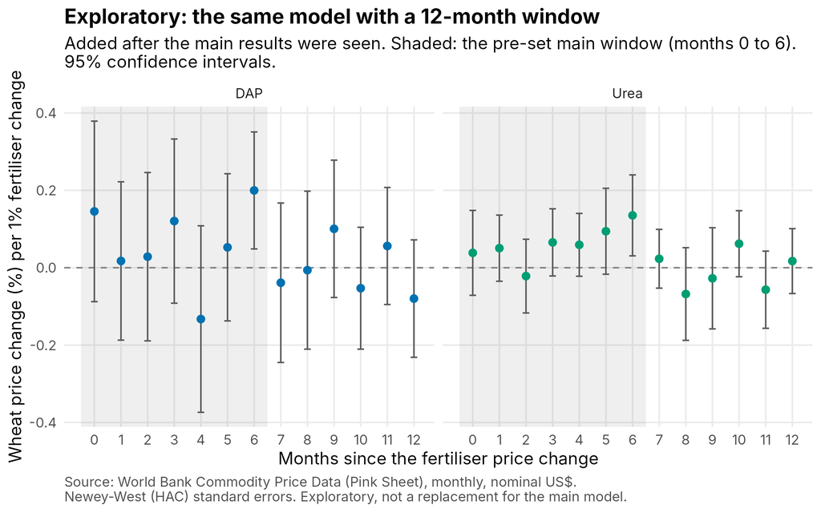

## 4.4 Does the direction matter? (Granger-type tests)

Small p-values mean past values of the first series help predict the second. They show predictive order, not causation. Twenty-four tests are run here, so with a 5% threshold one or two would be expected to look significant by chance alone (a strict Bonferroni cut-off would be about 0.002).

| Direction | Lags in test | F | p-value |
| --- | --- | --- | --- |
| DAP -> wheat | 1 | 1.553 | 0.215 |
| wheat -> DAP | 1 | 0.087 | 0.769 |
| DAP -> wheat | 2 | 0.928 | 0.398 |
| wheat -> DAP | 2 | 0.136 | 0.873 |
| DAP -> wheat | 3 | 0.859 | 0.464 |
| wheat -> DAP | 3 | 0.447 | 0.720 |
| DAP -> wheat | 4 | 0.728 | 0.574 |
| wheat -> DAP | 4 | 1.620 | 0.173 |
| DAP -> wheat | 5 | 1.201 | 0.313 |
| wheat -> DAP | 5 | 1.466 | 0.206 |
| DAP -> wheat | 6 | 1.488 | 0.188 |
| wheat -> DAP | 6 | 1.160 | 0.332 |
| Urea -> wheat | 1 | 0.812 | 0.369 |
| wheat -> Urea | 1 | 0.800 | 0.373 |
| Urea -> wheat | 2 | 0.401 | 0.670 |
| wheat -> Urea | 2 | 0.791 | 0.456 |
| Urea -> wheat | 3 | 0.311 | 0.817 |
| wheat -> Urea | 3 | 0.469 | 0.705 |
| Urea -> wheat | 4 | 0.964 | 0.430 |
| wheat -> Urea | 4 | 0.497 | 0.738 |
| Urea -> wheat | 5 | 2.321 | 0.047 |
| wheat -> Urea | 5 | 0.552 | 0.737 |
| Urea -> wheat | 6 | 3.734 | 0.002 |
| wheat -> Urea | 6 | 0.763 | 0.600 |

## 4.5 Robustness and sensitivity

**Sensitivity checks on the main specification.** The first checks whether the most recent months drive the result; the second removes the month in which the World Bank changed the urea benchmark.

| Fertiliser | Check | n | Cumulative | CI low | CI high | p-value |
| --- | --- | --- | --- | --- | --- | --- |
| DAP | main specification | 142 | 0.401 | 0.022 | 0.781 | 0.038 |
| DAP | sample ends Dec 2025 | 132 | 0.429 | 0.052 | 0.805 | 0.026 |
| Urea | main specification | 142 | 0.409 | 0.170 | 0.648 | 0.001 |
| Urea | sample ends Dec 2025 | 132 | 0.325 | 0.077 | 0.573 | 0.011 |
| Urea | urea benchmark change (Mar 2022) set to missing | 135 | 0.288 | 0.071 | 0.505 | 0.010 |

**Other lag lengths and control choices.**

| Fertiliser | Specification | n | Cumulative | CI low | CI high | p-value |
| --- | --- | --- | --- | --- | --- | --- |
| DAP | lags 0-3, no controls | 142 | 0.347 | 0.038 | 0.657 | 0.028 |
| DAP | lags 0-3 + energy controls | 142 | 0.287 | -0.047 | 0.621 | 0.092 |
| DAP | lags 0-6, no controls | 142 | 0.481 | 0.156 | 0.807 | 0.004 |
| DAP | lags 0-6 + energy controls | 142 | 0.401 | 0.022 | 0.781 | 0.038 |
| DAP | lags 0-12, no controls | 142 | 0.484 | 0.065 | 0.904 | 0.024 |
| DAP | lags 0-12 + energy controls | 142 | 0.411 | -0.100 | 0.922 | 0.114 |
| Urea | lags 0-3, no controls | 142 | 0.095 | -0.052 | 0.241 | 0.203 |
| Urea | lags 0-3 + energy controls | 142 | 0.037 | -0.118 | 0.193 | 0.636 |
| Urea | lags 0-6, no controls | 142 | 0.453 | 0.289 | 0.617 | 0.000 |
| Urea | lags 0-6 + energy controls | 142 | 0.409 | 0.170 | 0.648 | 0.001 |
| Urea | lags 0-12, no controls | 142 | 0.427 | 0.197 | 0.656 | 0.000 |
| Urea | lags 0-12 + energy controls | 142 | 0.372 | 0.095 | 0.649 | 0.009 |

## 4.6 Did the relationship change over time?

The rolling chart correlates this month’s wheat change with the **average fertiliser change over the previous three months**. That window is an analyst choice, made to match the question of delayed transmission.

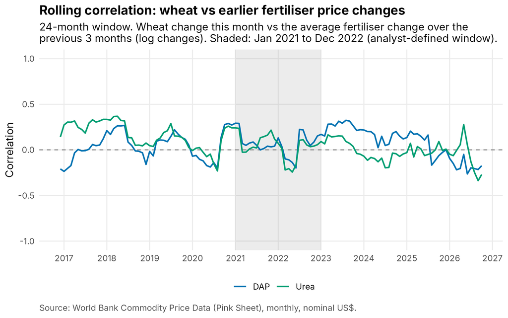

Sub-period estimates (months 0 to 3, no controls). **Treat with caution:** the shock window has few observations, so intervals are wide.

| Fertiliser | Period | Sample | n | Cumulative | CI low | CI high |
| --- | --- | --- | --- | --- | --- | --- |
| DAP | before shock window | 2015-01 to 2020-12 | 72 | 0.36 | -0.20 | 0.91 |
| DAP | shock window | 2021-01 to 2022-12 | 24 | 0.54 | -0.34 | 1.41 |
| DAP | after shock window | 2023-01 to 2026-10 | 46 | 0.10 | -0.30 | 0.50 |
| Urea | before shock window | 2015-01 to 2020-12 | 72 | 0.16 | -0.18 | 0.51 |
| Urea | shock window | 2021-01 to 2022-12 | 24 | 0.20 | -0.22 | 0.63 |
| Urea | after shock window | 2023-01 to 2026-10 | 46 | 0.00 | -0.27 | 0.27 |

# 5. Limitations

- **Nominal prices.** No inflation or exchange-rate adjustment. A general commodity boom or a dollar move can lift all prices together.
- **Benchmark export prices, not farm prices.** These are World Bank benchmark quotes, not what farmers pay or receive in any one country. The file’s Description sheet defines them as: wheat, US hard red winter (No. 2, Gulf export price; No. 1 ordinary protein up to June 2020); DAP, spot f.o.b. US Gulf; urea (Ukraine, prill), spot f.o.b. Black Sea until February 2022 and f.o.b. Middle East from March 2022.
- **Series definitions change inside the sample.** The urea quotation point changed in March 2022, in the middle of the shock window; I test this in section 4.5. The wheat benchmark grade changed around mid-2020. The European gas control switches from an import border price to the Dutch TTF price from April 2015, shortly after the sample starts.
- **Common shocks.** Energy prices affect both fertiliser and wheat; I control for oil and gas. Events such as the 2022 war in Ukraine plausibly hit both markets at once and are **not** separately controlled. The data also show a joint jump in oil, gas and urea in March 2026; section 4.5 shows what happens when the sample ends before 2026. I have not investigated its cause.
- **Short sub-samples.** The shock-window estimates rest on few months, so they cannot say whether the relationship changed.
- **Association only.** Regressions with lags and Granger-type tests show timing, not proven cause. Many tests were run, so isolated “significant” results should not be over-read.
- **The 12-month window is exploratory.** It was added after the main results were seen and should not be treated as a pre-planned test.

# 6. Interpretation

**Bottom line.** Between January 2015 and October 2026, rises in fertiliser prices went with higher wheat prices about five to six months later. The evidence is clearer for urea than for DAP, the effect is modest, and it is an association, not proof of cause.

# 7. Reproducibility

- Raw file used: `data/raw/CMO-Historical-Data-Monthly.xlsx`
- Rerun everything with `source("run_all.R")` from the project root.